# Static Report

Rohit Shivthare

October 2023

# Calculations

### Q1: Respondent Variables

#### Age Group

```
Percentage Distribution by Age
```

Percentage Distribution by Age

| Group | Percentage |
| --- | --- |
| 18-34 | 32.49 |
| 35-49 | 27.65 |
| 50-64 | 27.14 |
| 65+ | 12.72 |

#### Gender

```
Percentage Distribution by Gender
```

Percentage Distribution by Gender

| Group | Percentage |
| --- | --- |
| Female | 52.04 |
| Male | 46.91 |
| Other | 1.05 |

#### Income Group

```
Percentage Distribution by Income
```

Percentage Distribution by Income

| Group | Percentage |
| --- | --- |
| <50K | 34.24 |
| 50-75K | 15.61 |
| 75-100K | 19.49 |
| 100-150K | 22.14 |
| 150K+ | 8.52 |

#### Region

```
Percentage Distribution by Region
```

Percentage Distribution by Region

| Group | Percentage |
| --- | --- |
| Midwest | 24.60 |
| Northeast | 19.47 |
| South | 29.87 |
| West | 26.06 |

#### Persona

```
Percentage Distribution by Persona
```

Percentage Distribution by Persona

| Group | Percentage |
| --- | --- |
| Ambivalent Adventurer | 19.28 |
| Consistent Compromiser | 26.69 |
| Materialistic Meditator | 16.09 |
| Outdoorsy Ombudsman | 5.41 |
| Precociously Preoccupied | 24.03 |
| Technological Triumphalist | 8.50 |

### Q2: Segmented Outcomes

#### Part A

What are the top 5 products by Awareness rates in the Northeast?

```
Top 5 Products by Awareness Rates in Northeast
```

Top 5 Products by Awareness Rates in Northeast

| Product | Awareness_Rate |
| --- | --- |
| Speed Dials | 86.29 |
| Maybe Mobile | 86.24 |
| Triumphone | 83.98 |
| Mobzilla | 74.06 |
| Communic Nation | 71.29 |

#### Part B

What are the top 5 products by advocacy rates among female respondents who earn at least $100,000?

```
Top 5 Products by Advocacy Rates among Female with Income >= $ 1e+05
```

Top 5 Products by Advocacy Rates among Female with Income >= $ 1e+05

| Product | Advocacy_Rate |
| --- | --- |
| MobilitEE | 86.12 |
| Triumphone | 84.31 |
| No Buttons | 83.01 |
| Next Text | 82.99 |
| Ring Ring | 77.27 |

### Q3: Overall Brand Perceptions

What are the top 5 brands by the overall average perception?

Top 5 Brands by Overall Average Perception Scores

| Product | Overall_Average_Perception |
| --- | --- |
| Next Text | 7.12 |
| Cellularity | 6.85 |
| All Buttons | 6.47 |
| MobilitEE | 6.10 |
| Off the Hook | 6.06 |

### Q4: Gaps in Outcomes

#### Part A

Which 5 products have the largest gap between the rate of consumption and the rate of awareness? This would correspond to a formula of Difference = 100 * (Average Consumption - Average Awareness). (Please use this exact formula. Do not use the absolute value. Focus only on the highest positive gaps.) Display a bar graph showing the 5 largest differences in decreasing sorted order.

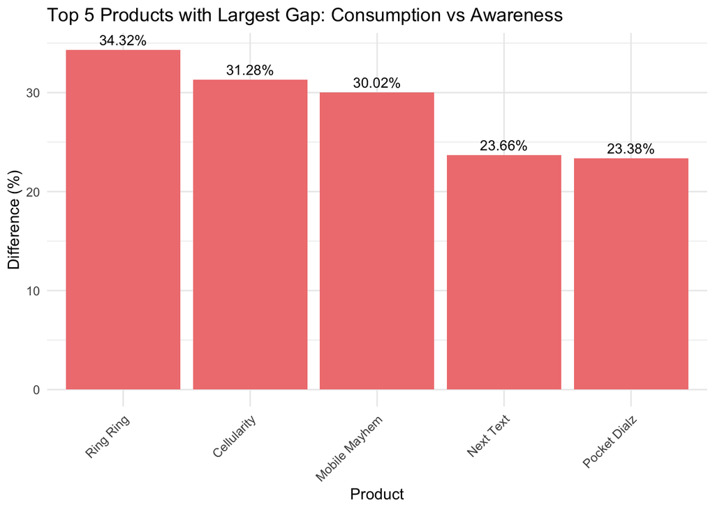

#### Part B

Which 5 products have the largest gap between the rate of awareness and the average satisfaction? This would correspond to a formula of Difference = 100 * (Average Awareness - Average Satisfaction). (Please use this exact formula. Do not use the absolute value. Focus only on the highest positive gaps.) Display a bar graph showing the 5 largest differences in decreasing sorted order.

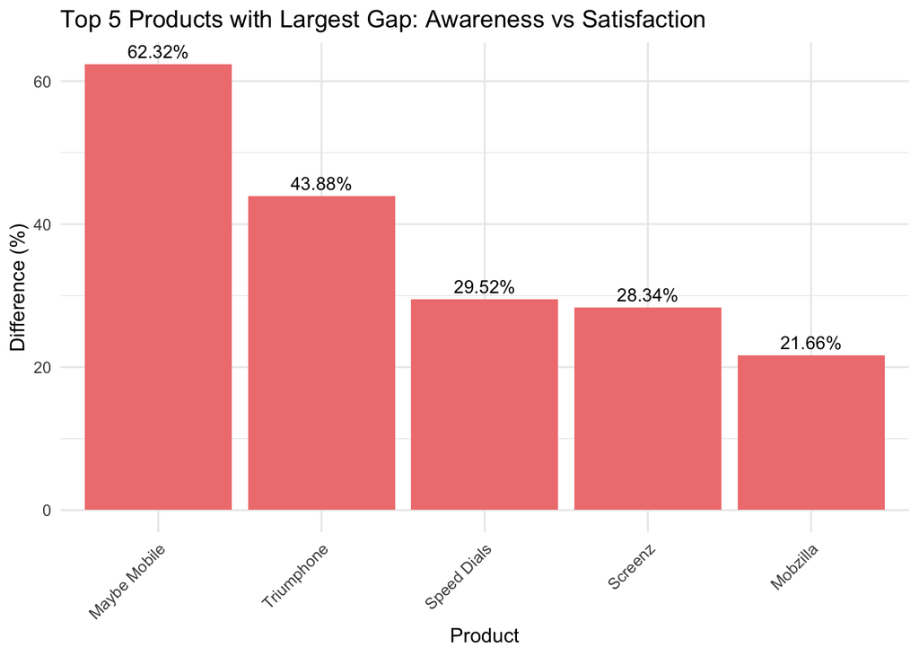

### Q5: Aggregated Engagement

#### Part A

How much impact does respondent’s overall trends in awareness have for that person’s awareness with Buzzdial phones?

```
# A tibble: 19 × 7
   term                        estim…¹ std.e…² statis…³  p.value conf.…⁴ conf.…⁵
   <chr>                         <dbl>   <dbl>    <dbl>    <dbl>   <dbl>   <dbl>
 1 (Intercept)                   0.628  0.147   -3.16   1.55e- 3   0.470   0.837
 2 Age_Group35-49                0.816  0.0569  -3.56   3.64e- 4   0.730   0.913
 3 Age_Group50-64                0.500  0.0614 -11.3    1.62e-29   0.443   0.564
 4 Age_Group65+                  0.475  0.0809  -9.20   3.53e-20   0.405   0.556
 5 GenderMale                    0.778  0.0468  -5.35   8.95e- 8   0.710   0.853
 6 GenderOther                   0.952  0.225   -0.221  8.25e- 1   0.603   1.46
 7 Income_Group50-75K            1.02   0.0704   0.264  7.91e- 1   0.887   1.17
 8 Income_Group75-100K           0.998  0.0657  -0.0357 9.71e- 1   0.877   1.13
 9 Income_Group100-150K          1.04   0.0629   0.575  5.65e- 1   0.916   1.17
10 Income_Group150K+             1.14   0.0869   1.55   1.21e- 1   0.964   1.36
11 RegionNortheast               1.36   0.0711   4.30   1.67e- 5   1.18    1.56
12 RegionSouth                   0.983  0.0668  -0.262  7.94e- 1   0.862   1.12
13 RegionWest                    2.12   0.0646  11.6    2.91e-31   1.87    2.41
14 PersonaConsistent Compromi…   1.04   0.0691   0.609  5.43e- 1   0.911   1.19
15 PersonaMaterialistic Medit…   1.13   0.0771   1.53   1.26e- 1   0.967   1.31
16 PersonaOutdoorsy Ombudsman    1.03   0.112    0.253  8.00e- 1   0.824   1.28
17 PersonaPrecociously Preocc…   1.03   0.0708   0.379  7.05e- 1   0.894   1.18
18 PersonaTechnological Trium…   0.836  0.0985  -1.81   6.97e- 2   0.689   1.01
19 Aggregated_engagement         0.457  0.212   -3.70   2.18e- 4   0.302   0.692
# … with abbreviated variable names ¹estimate, ²std.error, ³statistic,
#   ⁴conf.low, ⁵conf.high
```

#### Part B

How much impact does respondent’s overall trends in satisfaction have for that person’s satisfaction with Buzzdial phones?

```
# A tibble: 19 × 7
   term                       estimate std.e…¹ stati…² p.value conf.low conf.h…³
   <chr>                         <dbl>   <dbl>   <dbl>   <dbl>    <dbl>    <dbl>
 1 (Intercept)                 0.315    0.0503   6.26  2.83e-9  0.216    4.14e-1
 2 Age_Group35-49             -0.0381   0.0236  -1.61  1.08e-1 -0.0847   8.47e-3
 3 Age_Group50-64              0.0321   0.0275   1.17  2.45e-1 -0.0222   8.63e-2
 4 Age_Group65+               -0.102    0.0342  -3.00  3.13e-3 -0.170   -3.49e-2
 5 GenderMale                 -0.0297   0.0202  -1.47  1.44e-1 -0.0695   1.02e-2
 6 GenderOther                -0.129    0.0697  -1.85  6.57e-2 -0.267    8.49e-3
 7 Income_Group50-75K         -0.0391   0.0279  -1.40  1.63e-1 -0.0941   1.60e-2
 8 Income_Group75-100K        -0.0291   0.0320  -0.910 3.64e-1 -0.0922   3.40e-2
 9 Income_Group100-150K       -0.0568   0.0268  -2.12  3.57e-2 -0.110   -3.84e-3
10 Income_Group150K+          -0.00890  0.0318  -0.280 7.80e-1 -0.0717   5.39e-2
11 RegionNortheast             0.0278   0.0296   0.941 3.48e-1 -0.0305   8.61e-2
12 RegionSouth                 0.0132   0.0274   0.483 6.30e-1 -0.0409   6.74e-2
13 RegionWest                 -0.0554   0.0284  -1.96  5.21e-2 -0.111    5.16e-4
14 PersonaConsistent Comprom…  0.140    0.0407   3.42  7.65e-4  0.0591   2.20e-1
15 PersonaMaterialistic Medi…  0.126    0.0397   3.17  1.80e-3  0.0475   2.04e-1
16 PersonaOutdoorsy Ombudsman  0.0206   0.0626   0.329 7.43e-1 -0.103    1.44e-1
17 PersonaPrecociously Preoc… -0.00942  0.0308  -0.306 7.60e-1 -0.0702   5.13e-2
18 PersonaTechnological Triu…  0.105    0.0517   2.03  4.42e-2  0.00276  2.07e-1
19 Aggregated_engagement       0.0116   0.0627   0.185 8.53e-1 -0.112    1.35e-1
# … with abbreviated variable names ¹std.error, ²statistic, ³conf.high
```